# Ford GoBike System Analysis Presentation

## Precious Okon

## Investigation Overview

In this Presentation I want to take a look at how duration of rides relate to the different gender of riders, user type, start and end day, hour which the highest duration of ride.

My Key insights in this exploration is to find out the duration each gender takes on rides and which particular day and hour each gender like going on rides.

## Dataset Overview

This dataset contains information about individual rides made in a bike-sharing system covering the greater San Francisco Bay area. It contains 183412 rides and 16 features on each bike Id. About 8000 rows were removed from the dataset due to missing information.

New Columns start Day, Start Month, start Hour, end day, end month and end hour was introduced into the dataset and this column was extracted from start time and end time column. After cleaning and removing missing information we are now left with 174952 rides with 22 features.

## Distribution of Rides End Day

Most ride took place on Thurdays which is and most ride took place during the week days while less ride took place during weekend

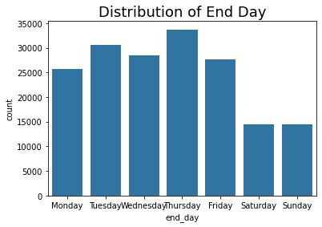

## Distribution of Rides Per Gender

The male Gender took the most ride with over 74% frequency

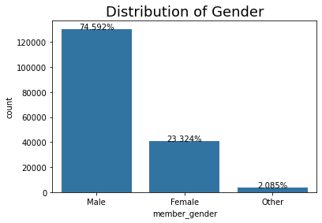

## Relationship Between Rides End Month and User Type

Subscriber generally had more ride than customers in the month of February

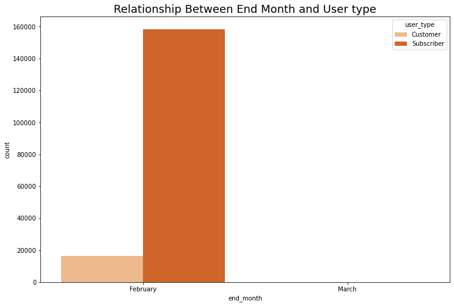

## Ride Duration Across Gender and User Type

Customers who were identified as Other gender had longer ride duration than male and female customers

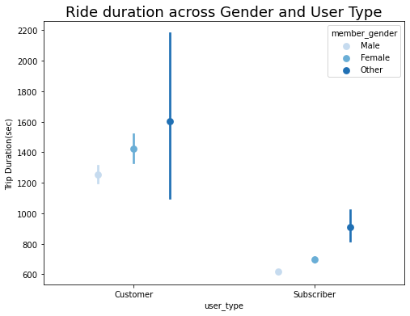

## Ride Duration Across Hour and Gender

The gender category Other has long duration when the start their ride with 2nd or 3rd hour

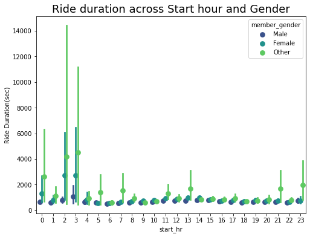

## Ride Duration Across Day and Gender

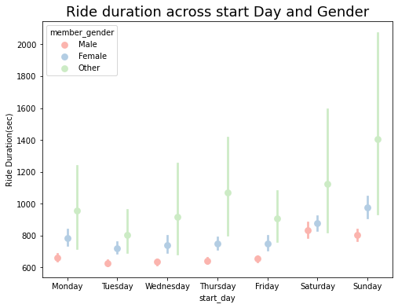